# Билет №1

# Сравнительный анализ текстового и бинарного форматов.

# Текстовый формат

**Текстовый файл** — компьютерный файл, содержащий текстовые данные,  
как правило, организованные в виде строк.

#### Преимущества текстового формата

- **Воспринимаемость человеком** — просто понять структуру и содержание, часто без документации и специальных инструментальных средств.
- **Простота** — формат крайне удобен и его можно редактировать огромным количеством инструментов. И в первую очередь простым текстовым редактором.
- **Версионируемость** — файлы легко сравнивать, находить изменения.
- **Переносимость** — текстовый файл может быть прочитан на любой системе или ОС.
- **Устойчивость** — каждое слово и символ в таком файле самодостаточны и, если случится повреждение байтов в таком файле, то обычно можно восстановить данные или продолжить обработку остального содержимого.

В эпоху быстрых компьютеров и дешевой памяти эти преимущества побеждают.

# Бинарный формат

**Двоичный (бинарный) файл** — в широком смысле: последовательность произвольных байтов.

#### Преимущества бинарного формата

- **Минимальный размер** — не содержат "разметки", часто являются сжатыми.
- **Машинное представление** данных, иногда допускает прямую (а значит быструю) загрузку в оперативную память (например сериализованные структуры данных). Нет необходимости в конверсии.
- **Эффективность** некоторых операций: поиск элементов, иногда вставка и удаление.

# Тестирование. Классификация тестов, критерии хорошего теста, инструменты.

# Классификация тестов: по масштабу

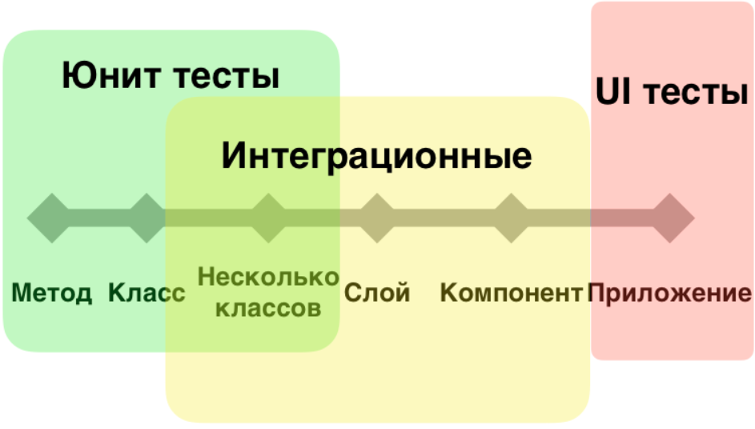

# Классификация тестов: по назначению

#### **Функциональные требования**

- На задымление (smoke)
  - Первый прогон программы (после написания или после внесения существенных изменений). Как правило, используется для определения, готова ли программа для проведения более обширного тестирования. Целью является выявление проблем «лежащих на поверхности» – тестируется чаще всего основная бизнес логика программы
- Регрессионные (regression) *Повторное тестирование после внесения изменений в программное обеспечение или в его окружение (в новой версии приложения), чтобы убедиться в том, что функции, которые работали в предыдущей версии системы, по-прежнему работают так, как ожидалось, а найденные дефекты успешно исправлены (все протестированное ранее тестируется повторно). Целью является выявление потенциальных проблем, которые могли возникнуть в результате изменений. Проверка исправления найденных ранее дефектов.
- На точность (accuracy)
  - Проверка корректности результатов выполнения программы.
- Соответствие/совместимость (conformance/compliance)
  - Проверка скомбинированных компонентов прикладной программы с целью определения корректности их совместного функционирования. Целью является выявление потенциальных проблем в совместном функционировании компонент.
- Приемочные (acceptance)
  - Первый и самый короткий тест, призванный проводить проверку основных элементов программного продукта и его работоспособности в целом. Проверяется основной функционал приложения. На основе результатов данного теста принимается решение о приемке версии программного продукта и продолжении тестирования текущей версии продукта более серьезными тестовыми испытаниями.
- Функциональные (functional)
  - Проверка соответствия продукта функциональным требованиям и спецификациям.

#### **Нефункциональные требования**

- На производительность (performance)
  - Проверка скорости работы системы (время отклика, частота транзакций и другие зависящие от времени) в имитационной и реальной средах. Целью - установить реальную производительность программного продукта.
- Стресс (stress)
  - Является одним из разновидностей тестирования на производительность. Проверяется поведение системы при недостатке ресурсов (дискового пространства, обрывов сети и т.д.).
- Нагрузочные (load)
  - Это те же тесты производительности, при которых система подвергается различным нагрузкам; при этом цель этого тестирования – оценить способность системы правильно функционировать при некотором превышении планируемых нагрузок при реальной эксплуатации (система имеет некоторый «запас прочности»). Цель - Убедиться в том, что система работает соответственно ожидаемым рабочим нагрузочным параметрам (какой предел работоспособности).
- Качество кода (code quality)
  - Проверка кода на соответствие стандартам написания кода, принятым внутри команды.

# Критерии хорошего теста

- Короткий (имеет чистый код)
  - Возможно быстро понять что тестируется и при каких условиях
- Сфокусированный (только один assert)
  - Позволяет мгновенно находить ошибку в коде программы при его модификации
- Быстрый
  - Выполняется за конечное время (обычно за доли секундб зависит от сложности теста)
- Автоматический
  - Не требует участия разработчика для выполнения
- Независим от порядка исполнения и окружения
  - Не использует специфические возможности компилятора/IDE/OS и т.д.
- Использует паттерн AAA: Arrange, Act, Assert
  - Общепринятый стандарт написания тестов

# Инструменты тестирования

Значительно упрощают создание и запуск unit-тестов, позволяют придерживаться единого стиля.

- xUnit — общее обозначение для подобных фреймворков. Бесплатно доступны для большинства языков:
- C/C++: CUnit, CPPUnit, GoogleTest
- Java: JUnit
- .NET: NUnit

Встроены в современные языки:

- D, Python, Go

#### Типичные возможности

- Удобное добавление тестов
  - Простая регистрация новых тестов
  - Набор функций-проверок (`assert`)
  - Общие инициализации и деинициализации
- Удобный запуск тестов
  - Пакетный режим
  - Возможность фильтрации тестов по именам
- Часто допускают интеграцию с IDE
- Генерация отчета в стандартном XML-формате
  - Возможность последующего автоматического анализа
  - Публикация на web-страницах проекта